# Tips and Tricks with Jupyter Notebooks

As presented at Brighton Data Forum 25/11/2020 by Sian Thompson

Starting Presentation

## Contents

In Parts...

1. [Setting up Virtual Environments for Python kernel](https://htmlpreview.github.io/?https://github.com/Kremzeeq/jupyter_notebooks_tips_and_tricks/blob/main/webpages/tips_and_tricks_p1.html)
2. [Package Management](https://htmlpreview.github.io/?https://github.com/Kremzeeq/jupyter_notebooks_tips_and_tricks/blob/main/webpages/tips_and_tricks_p2.html)
3. [Publishing your own Resources](https://htmlpreview.github.io/?https://github.com/Kremzeeq/jupyter_notebooks_tips_and_tricks/blob/main/webpages/tips_and_tricks_p3.html)
4. [Creating Interactive Dashboards](https://htmlpreview.github.io/?https://github.com/Kremzeeq/jupyter_notebooks_tips_and_tricks/blob/main/webpages/tips_and_tricks_p4.html)

## Part 1: Setting up Virtual Environments for Python kernel

This convers configuring a virtual environment to work with a specific Python version and use this within Jupyter Notebooks.

[figure not shown]

```python
from image_renderer import image_renderer

image_renderer(basewidth=600,image_path='../assets/rainbow_mountain.jpg')
```

### 1) Use conda to install specific python version:

```
conda create --name python3_8_env python=3.8
```

- For `name`, specify the name for your virtual environment

### 2) List virtual environments installed with conda:

```
conda info --envs
```

Example output:

```
# conda environments:
#
base                  *  /home/user/anaconda3
mydatasci                /home/user/anaconda3/envs/mydatasci
python3_8_env            /home/user/anaconda3/envs/python3_8_env
```

### 3) Activate the environment:

```
conda activate python3_8_env
```

### 4) Check for the basic requirements in the venv:

We list installed libaries through using 'conda list', as opposed to 'pip freeze':

```
(python3_8_env) user@yourmachine: conda list
```

Here are the minimum key libraries I would expect to see with any venv configured for python:

```
# packages in environment at /home/sian/anaconda3/envs/python3_8_env:
#
# Name                    Version                   Build  Channel
pip                       20.2.3                   py38_0
python                    3.8.5                h7579374_1   <- We can check the python version here
setuptools                50.3.0           py38hb0f4dca_1
wheel                     0.35.1                     py_0
```

### 5) Install ipykernel library required for setting up the Python kernel:

Generally, when installing packages for Jupyter Notebooks, stick to using conda install instead of pip. Conda can accommodate the python interpreter as well as pip.

```
(python3_8_env) user@yourmachine: conda install ipykernel
```

This will prompt for installing further libraries including ipython, jupyter_client and jupyter_core

### 6) Install the kernel using ipython:

When you specify the name for the kernel, suggest naming this the same as the activated venv you are using:

```
(python3_8_env) user@yourmachine: ipython kernel install --user --name=python3_8_env
```

### 7) Restart Jupyter Notebook and select the newly set up kernel in your notebook project:

It should be possible to select the python kernel under the 'Change kernel' option, in the 'Kernel' dropdown menu within your Jupyter notebook. Typically, 'Python 3' will be the default kernel.

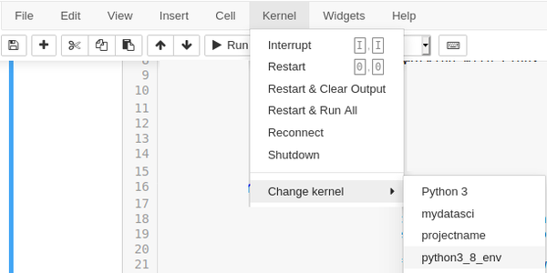

```python
image_renderer(basewidth=600,image_path='../assets/kernel_selection.png')
```

When you not longer need to work with your venv in the terminal, you can simple deactivate it:

```
(python3_8_env) user@yourmachine: conda deactivate
```

[Next | Part 2: Package Management](https://htmlpreview.github.io/?https://github.com/Kremzeeq/jupyter_notebooks_tips_and_tricks/blob/main/webpages/tips_and_tricks_p2.html)

```python
%%html
<style type="text/css">
div.jp-InputArea {
    display:none;
}
div.input {
    display:none;
}
</style>
```